# Python

- 自学 Python 第八天
- 详细的学习tensorflow
- 本文参考了该[网址](https://www.icourse163.org/learn/ZUCC-1206146808?tid=1450260446#/learn/content?type=detail&id=1214536554&cid=1218308906&replay=true)
- 有监督学习：指的是事先需要准备好输入与正确的输出（区分方法）相配套的训练数据，让计算机进行学习，一遍当它被输入某个数据时能够得到正确的输出（区分方法）；比如 逻辑回归，决策树，KNN,随机森林，支持向量机等
- 无监督学习的目的是让计算机自己去学习做一些事情。所有数据只有特征而没有标记；
- 半监督学习，其训练数据一部分有标记，另一部分无标记，而没有标记数据的量往往极大于有标记数据的数量；
- 强化学习是解决计算机从感知到决策控制的问题，从而实现通用人工智能；强化学习是目标导向的，从白纸一张的状态开始，经由许多步骤来实现某一个维度上的目标最大化。最简单的理解在训练过程，不断的尝试，错误就惩罚，正确就奖励，由此训练得到的模型在各个状态环境中都表现的最好。

## 安装 TensorFlow

- 因为国外网站比较慢，所以我们先更改镜像；
- 打开Anaconda Prompt
- 执行 `conda config --add channels https://mirrors.tuna.tsinghua.edu.cn/anaconda/pkgs/free/`
- 再执行`conda cofig --set show_channel_urls yes`
- 用编辑器打开.condrac(`C:\Users\asus`),然后删除第三行-defaults,并保存
- 执行`conda install tensorflow`或者`conda install tensorflow-gpu`安装TensorFlow.

```python
import tensorflow as tf
```

```python
tf.__version__
```

```
'2.1.0'
```

- 如果要实现print输出不换行，需要指定结尾符：end="".例如

```python
print("hello",end=" ")
print("world")
```

```
hello world
```

```python
set1={1,2,3}
set2={2,4,5}
```

```python
set1 | set2 #集合的并
```

```
{1, 2, 3, 4, 5}
```

```python
set1 & set2 #集合的交
```

```
{2}
```

```python
set1-set2#集合的差
```

```
{1, 3}
```

```python
(set1 | set2)-(set1 & set2)
```

```
{1, 3, 4, 5}
```

## tensorflow编程基础

```python
import tensorflow as tf
```

```python
node1 = tf.constant([[3.,1.5],[2.5,6.]])
node2 = tf.constant([[4.,1.],[5.,2.5]])
node3=tf.add(node1,node2)#加，.sub是减
node3
```

```
<tf.Tensor: shape=(2, 2), dtype=float32, numpy=
array([[7. , 2.5],
       [7.5, 8.5]], dtype=float32)>
```

```python
node1
```

```
<tf.Tensor: shape=(2, 2), dtype=float32, numpy=
array([[3. , 1.5],
       [2.5, 6. ]], dtype=float32)>
```

```python
node2
```

```
<tf.Tensor: shape=(2, 2), dtype=float32, numpy=
array([[4. , 1. ],
       [5. , 2.5]], dtype=float32)>
```

```python
print(node2.numpy())##只输出数字，不输出其他的
```

```
[[4.  1. ]
 [5.  2.5]]
```

#### tensorflow是一个通过计算图的形式表示计算的编程系统。每一个计算都是计算图上的一个节点，节点之间的边描述了计算之间的关系。

```python
vec = tf.constant([1,2,3,4,5])
print(vec.shape)
```

```
(5,)
```

```python
print(vec.get_shape())
```

```
(5,)
```

- 在tensorflow中，必须是相同的类型数据才能相加减，另外，可以用tf.cast()进行数据类型转换。
- 常量：在运行中值不会改变

tf.constant(value,dtype=None,shape=None,name="Const")

- 变量 tf.Variable(initial_value,dtype=None,shape=None,trainable=True,name="Variable")
- 变量在创建时必须确定初始值，可以向常量一样确定
- 在变量的参数中，trainable参数用来表征当前变量是否需要被优化，默认是True

```python
v1 = tf.Variable([1,2])
v1
```

```
<tf.Variable 'Variable:0' shape=(2,) dtype=int32, numpy=array([1, 2])>
```

```python
c=tf.constant(1)
v=tf.Variable(c)
v
```

```
<tf.Variable 'Variable:0' shape=() dtype=int32, numpy=1>
```

### 如果要用tensorflow1版本，则需要执行

- import tensorflow.compat.v1 as tf
- tf.disable_eager_execution()

## tensorflow在线性模型中的应用

- 生成数据
- 构建线性模型
- 定义损失函数
- 定义优化器、最小化损失函数
- 训练结果可视化
- 预测

```python
%matplotlib inline
```

- 上式是为了在jupyter中显示图片，否则不会显示

```python
import matplotlib.pyplot as plt
import numpy as np
import tensorflow as tf
```

```python
x_data= np.linspace(-1,1,200)
y_data=2*x_data+1.0+np.random.randn(*x_data.shape)*0.4
```

```python
x_data.shape#出来是一个元组，不是整形，所以用*x_data.shape，将整数弄出来
```

```
(200,)
```

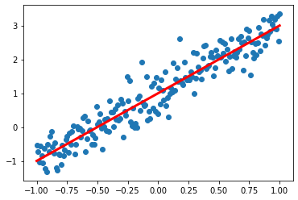

```python
plt.scatter(x_data,y_data)
plt.plot(x_data,x_data*2+1.,color="red",linewidth=3)
```

### 定义模型函数

```python
def model(x,w,b):
    return tf.multiply(x,w)+b
```

### 定义变量名

```python
w = tf.Variable(1.,name="w0")
b = tf.Variable(0.,name="b0")
```

### 定义损失函数

```python
def loss(x,y,w,b):
    err=model(x,w,b)-y
    squared=tf.square(err)
    return tf.reduce_mean(squared)
```

### 训练模型

#### 设置超参数

```python
training_epochs=10
learning_rate=0.01
```

#### 定义计算梯度函数

```python
def grad(x,y,w,b):
    with tf.GradientTape() as tape:
        loss_=loss(x,y,w,b)
    return tape.gradient(loss_,[w,b])
```

### 执行训练：（SGD）

```python
step=0#记录训练步数
loss_list=[]#保存loss值
display_step=50#控制训练过程数据显示频率
```

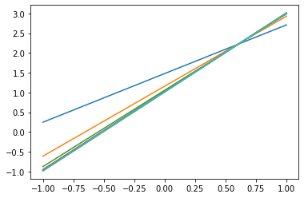

```python
for epoch in range(training_epochs):
    for xs,ys in zip(x_data,y_data):
        loss_=loss(xs,ys,w,b)
        loss_list.append(loss_)
        delta_w,delta_b=grad(xs,ys,w,b)##计算当前梯度
        change_w=delta_w*learning_rate
        change_b=delta_b*learning_rate
        w.assign_sub(change_w)#变量w的值更变为w-change_w
        b.assign_sub(change_b)

        step=step+1

        #if step % display_step==0:
        #    print("Training Epochs:","%02d" % (epoch+1),"step:%03d" % (step))
    plt.plot(x_data,w.numpy()*x_data+b.numpy())
```

```python
print(w.numpy())
print(w.numpy())
```

[output not shown]

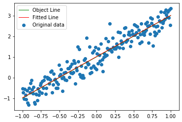

```python
plt.scatter(x_data,y_data,label="Original data")
plt.plot(x_data,x_data*2.+1.,label="Object Line",color="g",linewidth=1)
plt.plot(x_data,x_data*w.numpy()+b.numpy(),label="Fitted Line",color="r",linewidth=1)
plt.legend(loc=2)
```

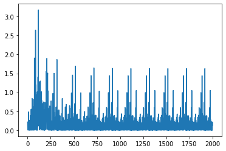

```python
plt.plot(loss_list)
```

## 多元线性回归的在tensorflow中的应用：波士顿房价预测

```python
%matplotlib notebook
import matplotlib.pyplot as plt
import numpy as np
import pandas as pd
import tensorflow as tf
from sklearn import datasets
from sklearn.utils import shuffle#用于打乱数据
from sklearn.preprocessing import scale
```

```python
from sklearn.datasets import load_boston#插入数据
```

```python
boston = load_boston()
X = boston.data
y = boston.target
df = pd.DataFrame(X, columns= boston.feature_names)
```

```python
print(df.describe())
```

```
             CRIM          ZN       INDUS        CHAS         NOX          RM  \
count  506.000000  506.000000  506.000000  506.000000  506.000000  506.000000
mean     3.613524   11.363636   11.136779    0.069170    0.554695    6.284634
std      8.601545   23.322453    6.860353    0.253994    0.115878    0.702617
min      0.006320    0.000000    0.460000    0.000000    0.385000    3.561000
25%      0.082045    0.000000    5.190000    0.000000    0.449000    5.885500
50%      0.256510    0.000000    9.690000    0.000000    0.538000    6.208500
75%      3.677083   12.500000   18.100000    0.000000    0.624000    6.623500
max     88.976200  100.000000   27.740000    1.000000    0.871000    8.780000

              AGE         DIS         RAD         TAX     PTRATIO           B  \
count  506.000000  506.000000  506.000000  506.000000  506.000000  506.000000
mean    68.574901    3.795043    9.549407  408.237154   18.455534  356.674032
std     28.148861    2.105710    8.707259  168.537116    2.164946   91.294864
min      2.900000    1.129600    1.000000  187.000000   12.600000    0.320000
25%     45.025000    2.100175    4.000000  279.000000   17.400000  375.377500
50%     77.500000    3.207450    5.000000  330.000000   19.050000  391.440000
75%     94.075000    5.188425   24.000000  666.000000   20.200000  396.225000
max    100.000000   12.126500   24.000000  711.000000   22.000000  396.900000

            LSTAT
count  506.000000
mean    12.653063
std      7.141062
min      1.730000
25%      6.950000
50%     11.360000
75%     16.955000
max     37.970000
```

```python
df.shape
```

```
(506, 13)
```

- np.multiply(A,B)与A*B等价

```python
df = np.array(df)
```

```python
for i in range(13):
    df[:,i]=df[:,i]/(df[:,i].max()-df[:,i].min())
```

```python
x_data=np.array(df)
x_data.shape
```

```
(506, 13)
```

```python
x_data
```

```
array([[7.10352762e-05, 1.80000000e-01, 8.46774194e-02, ...,
        1.62765957e+00, 1.00080690e+00, 1.37417219e-01],
       [3.06957815e-04, 0.00000000e+00, 2.59164223e-01, ...,
        1.89361702e+00, 1.00080690e+00, 2.52207506e-01],
       [3.06733020e-04, 0.00000000e+00, 2.59164223e-01, ...,
        1.89361702e+00, 9.90544153e-01, 1.11203091e-01],
       ...,
       [6.82927750e-04, 0.00000000e+00, 4.37316716e-01, ...,
        2.23404255e+00, 1.00080690e+00, 1.55629139e-01],
       [1.23176518e-03, 0.00000000e+00, 4.37316716e-01, ...,
        2.23404255e+00, 9.92107519e-01, 1.78807947e-01],
       [5.32876969e-04, 0.00000000e+00, 4.37316716e-01, ...,
        2.23404255e+00, 1.00080690e+00, 2.17439294e-01]])
```

```python
y_data=np.array(y)
y.shape
```

```
(506,)
```

### 划分数据

```python
train_num=300
valid_num=100
test_num=len(x_data)-300-100
```

```python
x_train=x_data[:train_num]
y_train=y_data[:train_num]
x_valid=x_data[train_num:train_num+valid_num]
y_valid=y_data[train_num:train_num+valid_num]
x_test=x_data[train_num+valid_num:train_num+valid_num+test_num]
y_test=y_data[train_num+valid_num:train_num+valid_num+test_num]
```

```python
x_train=tf.cast(x_train,dtype=tf.float32)
x_valid=tf.cast(x_valid,dtype=tf.float32)
x_test=tf.cast(x_test,dtype=tf.float32)
```

- 上一步是将数据转化为float32型，否则无法计算，比如矩阵相乘

```python
x_train.shape
```

```
TensorShape([300, 13])
```

### 定义模型函数

```python
def model(x,w,b):
    return tf.matmul(x,w)+b
```

```python
w = tf.Variable(tf.random.normal([13,1],mean=0.,stddev=1,dtype=tf.float32))
b = tf.Variable(1.)
```

```python
training_epochs=100
learning_rate=0.01
batch_size=10
```

```python
def loss(x,y,w,b):
    err=model(x,w,b)-y
    squared=tf.square(err)
    return tf.reduce_mean(squared)
```

```python
def grad(x,y,w,b):
    with tf.GradientTape() as tape:
        loss_=loss(x,y,w,b)
    return tape.gradient(loss_,[w,b])
```

- 定义优化器

```python
optimizer = tf.keras.optimizers.SGD(learning_rate)
```

```python
loss_list_train=[]
loss_list_valid=[]
total_step=int(train_num/batch_size)
for epoch in range(training_epochs):
    for step in range(total_step):
        xs=x_train[step*batch_size:(step+1)*batch_size,:]
        ys=y_train[step*batch_size:(step+1)*batch_size]
        grads=grad(xs,ys,w,b)
        optimizer.apply_gradients(zip(grads,[w,b]))
    loss_train=loss(x_train,x_train,w,b).numpy()
    loss_valid=loss(x_valid,x_valid,w,b).numpy()
    loss_list_train.append(loss_train)
    loss_list_valid.append(loss_valid)
    #print("epoch={:3d},train_loss={:.4f},valid_loss={:.4f}".format(epoch+1,loss_train,loss_valid))
```

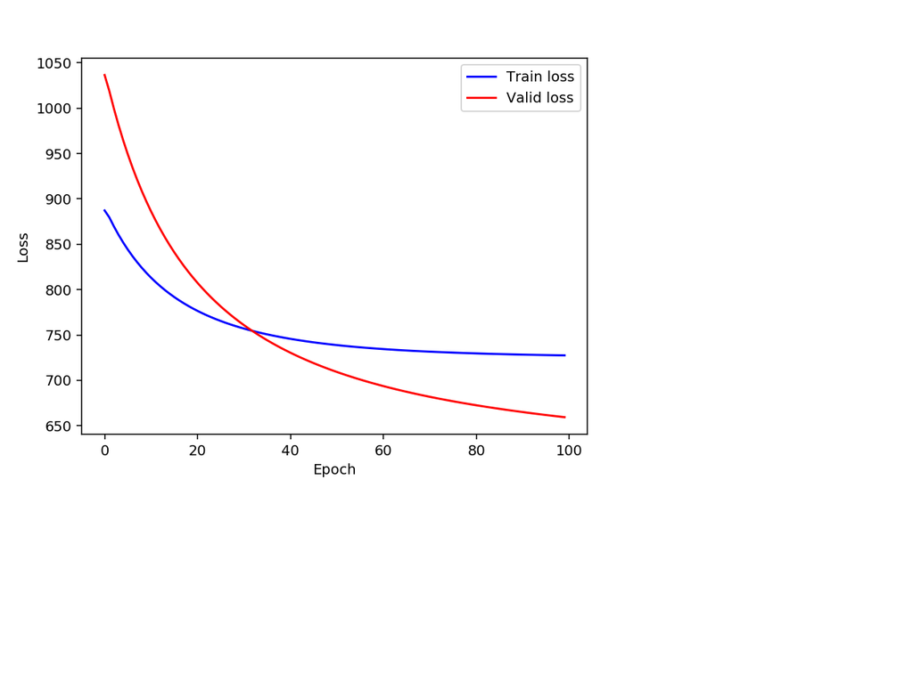

```python
plt.xlabel("Epoch")
plt.ylabel("Loss")
plt.plot(loss_list_train,"blue",label="Train loss")
plt.plot(loss_list_valid,"red",label="Valid loss")
plt.legend(loc=1)
```

```python
w.numpy()
```

```
array([[ 0.8627046 ],
       [ 2.0347915 ],
       [-2.3264868 ],
       [ 2.4200652 ],
       [ 2.3835468 ],
       [16.064892  ],
       [ 0.5469849 ],
       [-0.48429352],
       [ 1.7022905 ],
       [ 1.2205215 ],
       [-5.0149765 ],
       [ 5.5559187 ],
       [-6.4485297 ]], dtype=float32)
```

```python
b.numpy()
```

```
9.9485
```

## Mnist手写数字识别(单层神经网络)

```python
import tensorflow as tf
import matplotlib.pyplot as plt
import numpy as np
import pandas as pd
```

```python
mnist = tf.keras.datasets.mnist
```

```python
(train_images,train_labels),(test_images,test_labels)=mnist.load_data()
```

```python
train_images.shape
```

```
(60000, 28, 28)
```

```python
train_labels.shape
```

```
(60000,)
```

```python
train_labels
```

```
array([5, 0, 4, ..., 5, 6, 8], dtype=uint8)
```

#### 可视化

```python
def plot_image(image):
    plt.imshow(image.reshape(28,28),cmap="binary")#binary为灰度
    plt.show()
```

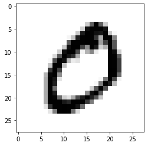

```python
plot_image(train_images[1])
```

#### 数据划分

```python
total_num=len(train_images)
train_num=int(total_num*0.8)
train_x=train_images[:train_num]
train_y=train_labels[:train_num]
valid_x=train_images[train_num:]
valid_y=train_labels[train_num:]
test_x=test_images
test_y=test_labels
```

```python
valid_x.shape
```

```
(12000, 28, 28)
```

```python
train_x = train_x.reshape(-1,784)##把每一行拉直
valid_x = valid_x.reshape(-1,784)
test_x = test_x.reshape(-1,784)
```

```python
train_x=tf.cast(train_x/255.,dtype=tf.float32)
valid_x=tf.cast(valid_x/255.,dtype=tf.float32)
test_x=tf.cast(test_x/255.,dtype=tf.float32)
```

```python
train_y=tf.one_hot(train_y,depth=10)
valid_y=tf.one_hot(valid_y,depth=10)
test_y=tf.one_hot(test_y,depth=10)
```

```python
train_y
```

```
<tf.Tensor: shape=(48000, 10), dtype=float32, numpy=
array([[0., 0., 0., ..., 0., 0., 0.],
       [1., 0., 0., ..., 0., 0., 0.],
       [0., 0., 0., ..., 0., 0., 0.],
       ...,
       [1., 0., 0., ..., 0., 0., 0.],
       [0., 1., 0., ..., 0., 0., 0.],
       [0., 0., 1., ..., 0., 0., 0.]], dtype=float32)>
```

```python
def model(x,w,b):
    pred=tf.matmul(x,w)+b
    return tf.nn.softmax(pred)
```

```python
w = tf.Variable(tf.random.normal([784,10],mean=0.,stddev=1,dtype=tf.float32))
b = tf.Variable(tf.zeros([10]),dtype=tf.float32)
```

#### 定义损失函数（交叉熵损失函数）

```python
def loss(x,y,w,b):
    pred=model(x,w,b)
    loss_=tf.keras.losses.categorical_crossentropy(y_true=y,y_pred=pred)
    return tf.reduce_mean(loss_)
```

```python
training_epochs=20
learning_rate=0.01
batch_size=50
```

```python
def grad(x,y,w,b):
    with tf.GradientTape() as tape:
        loss_=loss(x,y,w,b)
    return tape.gradient(loss_,[w,b])
```

```python
optimizer = tf.keras.optimizers.Adam(learning_rate)
```

#### 定义准确率

```python
def accuracy(x,y,w,b):
    pred=model(x,w,b)
    correct_prediction = tf.equal(tf.argmax(pred,1),tf.argmax(y,1))
    return tf.reduce_mean(tf.cast(correct_prediction,tf.float32))
```

```python
total_step = int(train_num/batch_size)
loss_list_train=[]
loss_list_valid=[]
acc_list_train=[]
acc_list_valid=[]

for epoch in range(training_epochs):
    for step in range(total_step):
        xs=train_x[step*batch_size:(step+1)*batch_size,:]
        ys=train_y[step*batch_size:(step+1)*batch_size]
        grads=grad(xs,ys,w,b)
        optimizer.apply_gradients(zip(grads,[w,b]))
    loss_train=loss(train_x,train_y,w,b).numpy()
    loss_valid=loss(valid_x,valid_y,w,b).numpy()
    acc_train=accuracy(train_x,train_y,w,b).numpy()
    acc_valid=accuracy(valid_x,valid_y,w,b).numpy()
    loss_list_train.append(loss_train)
    loss_list_valid.append(loss_valid)
    acc_list_train.append(acc_train)
    acc_list_valid.append(acc_valid)
    #print("epoch={:3d},train_loss={:.4f},valid_loss={:.4f}".format(epoch+1,loss_train,loss_valid))
```

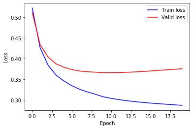

```python
plt.xlabel("Epoch")
plt.ylabel("Loss")
plt.plot(loss_list_train,"blue",label="Train loss")
plt.plot(loss_list_valid,"red",label="Valid loss")
plt.legend(loc=1)
```

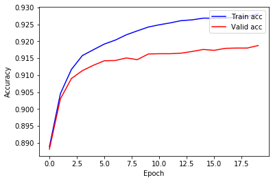

```python
plt.xlabel("Epoch")
plt.ylabel("Accuracy")
plt.plot(acc_list_train,"blue",label="Train acc")
plt.plot(acc_list_valid,"red",label="Valid acc")
plt.legend(loc=1)
```

```python
accuracy(test_x,test_y,w,b)
```

```
<tf.Tensor: shape=(), dtype=float32, numpy=0.913>
```

## Mnist数字识别（一层神经网络）

```python
import tensorflow as tf
import matplotlib.pyplot as plt
import numpy as np
import pandas as pd
```

```python
mnist = tf.keras.datasets.mnist
(train_images,train_labels),(test_images,test_labels)=mnist.load_data()
```

```python
total_num=len(train_images)
train_num=int(total_num*0.8)
train_x=train_images[:train_num]
train_y=train_labels[:train_num]

valid_x=train_images[train_num:]
valid_y=train_labels[train_num:]

test_x=test_images
test_y=test_labels
```

```python
train_x = train_x.reshape(-1,784)##把每一行拉直
valid_x = valid_x.reshape(-1,784)
test_x = test_x.reshape(-1,784)
```

```python
train_x=tf.cast(train_x/255.,dtype=tf.float32)
valid_x=tf.cast(valid_x/255.,dtype=tf.float32)
test_x=tf.cast(test_x/255.,dtype=tf.float32)
```

```python
train_y=tf.one_hot(train_y,depth=10)
valid_y=tf.one_hot(valid_y,depth=10)
test_y=tf.one_hot(test_y,depth=10)
```

```python
## 定义第一层隐藏层的权重和斜率
Imput_dim=784
H1_NN=64
w1 = tf.Variable(tf.random.normal([Imput_dim,H1_NN],mean=0.,stddev=1,dtype=tf.float32))
b1 = tf.Variable(tf.zeros([H1_NN]),dtype=tf.float32)
```

```python
## 定义输出隐藏层的权重和斜率
Output_dim=10
w2 = tf.Variable(tf.random.normal([H1_NN,Output_dim],mean=0.,stddev=1,dtype=tf.float32))
b2 = tf.Variable(tf.zeros([Output_dim]),dtype=tf.float32)
```

```python
#建立待优化的列表
w=[w1,w2]
b=[b1,b2]
```

```python
def model(x,w,b):
    x=tf.matmul(x,w[0])+b[0]
    x=tf.nn.relu(x)
    x=tf.matmul(x,w[1])+b[1]
    pre=tf.nn.softmax(x)
    return pre
```

```python
def loss(x,y,w,b):
    pred=model(x,w,b)
    loss_=tf.keras.losses.categorical_crossentropy(y_true=y,y_pred=pred)
    return tf.reduce_mean(loss_)
```

```python
training_epochs=20
learning_rate=0.01
batch_size=50
```

```python
def grad(x,y,w,b):
    with tf.GradientTape() as tape:
        loss_=loss(x,y,w,b)
    return tape.gradient(loss_,w+b)##这里跟之前没有因此层不一样！！！
```

```python
optimizer = tf.keras.optimizers.Adam(learning_rate)
```

```python
def accuracy(x,y,w,b):
    pred=model(x,w,b)
    correct_prediction = tf.equal(tf.argmax(pred,1),tf.argmax(y,1))
    return tf.reduce_mean(tf.cast(correct_prediction,tf.float32))
```

```python
total_step = int(train_num/batch_size)
loss_list_train=[]
loss_list_valid=[]
acc_list_train=[]
acc_list_valid=[]

for epoch in range(training_epochs):
    for step in range(total_step):
        xs=train_x[step*batch_size:(step+1)*batch_size,:]
        ys=train_y[step*batch_size:(step+1)*batch_size]
        grads=grad(xs,ys,w,b)
        optimizer.apply_gradients(zip(grads,w+b))
    loss_train=loss(train_x,train_y,w,b).numpy()
    loss_valid=loss(valid_x,valid_y,w,b).numpy()
    acc_train=accuracy(train_x,train_y,w,b).numpy()
    acc_valid=accuracy(valid_x,valid_y,w,b).numpy()
    loss_list_train.append(loss_train)
    loss_list_valid.append(loss_valid)
    acc_list_train.append(acc_train)
    acc_list_valid.append(acc_valid)
```

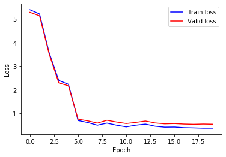

```python
plt.xlabel("Epoch")
plt.ylabel("Loss")
plt.plot(loss_list_train,"blue",label="Train loss")
plt.plot(loss_list_valid,"red",label="Valid loss")
plt.legend(loc=1)
```

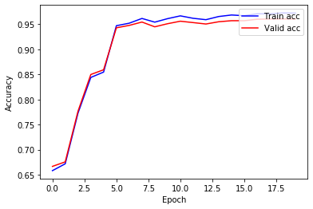

```python
plt.xlabel("Epoch")
plt.ylabel("Accuracy")
plt.plot(acc_list_train,"blue",label="Train acc")
plt.plot(acc_list_valid,"red",label="Valid acc")
plt.legend(loc=1)
```

```python
accuracy(test_x,test_y,w,b)
```

```
<tf.Tensor: shape=(), dtype=float32, numpy=0.9602>
```

## Mnist数字识别（两层层神经网络，效果并不一定比单层神经网络好）

```python
import tensorflow as tf
import matplotlib.pyplot as plt
import numpy as np
import pandas as pd
```

```python
mnist = tf.keras.datasets.mnist
(train_images,train_labels),(test_images,test_labels)=mnist.load_data()
```

```python
total_num=len(train_images)
train_num=int(total_num*0.8)
train_x=train_images[:train_num]
train_y=train_labels[:train_num]

valid_x=train_images[train_num:]
valid_y=train_labels[train_num:]

test_x=test_images
test_y=test_labels
```

```python
train_x = train_x.reshape(-1,784)##把每一行拉直
valid_x = valid_x.reshape(-1,784)
test_x = test_x.reshape(-1,784)
```

```python
train_x=tf.cast(train_x/255.,dtype=tf.float32)
valid_x=tf.cast(valid_x/255.,dtype=tf.float32)
test_x=tf.cast(test_x/255.,dtype=tf.float32)
```

```python
train_y=tf.one_hot(train_y,depth=10)
valid_y=tf.one_hot(valid_y,depth=10)
test_y=tf.one_hot(test_y,depth=10)
```

```python
## 定义第一层隐藏层的权重和斜率
Imput_dim=784
H1_NN=64
w1 = tf.Variable(tf.random.normal([Imput_dim,H1_NN],mean=0.,stddev=1,dtype=tf.float32))
b1 = tf.Variable(tf.zeros([H1_NN]),dtype=tf.float32)
```

```python
## 定义第二层隐藏层的权重和斜率
H2_NN=32
w2 = tf.Variable(tf.random.normal([H1_NN,H2_NN],mean=0.,stddev=1,dtype=tf.float32))
b2 = tf.Variable(tf.zeros([H2_NN]),dtype=tf.float32)
```

```python
## 定义输出隐藏层的权重和斜率
Output_dim=10
w3 = tf.Variable(tf.random.normal([H2_NN,Output_dim],mean=0.,stddev=1,dtype=tf.float32))
b3 = tf.Variable(tf.zeros([Output_dim]),dtype=tf.float32)
```

```python
#建立待优化的列表
w=[w1,w2,w3]
b=[b1,b2,b3]
```

```python
def model(x,w,b):
    x=tf.matmul(x,w[0])+b[0]
    x=tf.nn.relu(x)
    x=tf.matmul(x,w[1])+b[1]
    x=tf.nn.relu(x)
    x=tf.matmul(x,w[2])+b[2]
    pre=tf.nn.softmax(x)
    return pre
```

```python
def loss(x,y,w,b):
    pred=model(x,w,b)
    loss_=tf.keras.losses.categorical_crossentropy(y_true=y,y_pred=pred)
    return tf.reduce_mean(loss_)
```

```python
training_epochs=100
learning_rate=0.001
batch_size=50
```

```python
def grad(x,y,w,b):
    with tf.GradientTape() as tape:
        loss_=loss(x,y,w,b)
    return tape.gradient(loss_,w+b)
```

```python
optimizer = tf.keras.optimizers.Adam(learning_rate)
```

```python
def accuracy(x,y,w,b):
    pred=model(x,w,b)
    correct_prediction = tf.equal(tf.argmax(pred,1),tf.argmax(y,1))
    return tf.reduce_mean(tf.cast(correct_prediction,tf.float32))
```

```python
total_step = int(train_num/batch_size)
loss_list_train=[]
loss_list_valid=[]
acc_list_train=[]
acc_list_valid=[]

for epoch in range(training_epochs):
    for step in range(total_step):
        xs=train_x[step*batch_size:(step+1)*batch_size,:]
        ys=train_y[step*batch_size:(step+1)*batch_size]
        grads=grad(xs,ys,w,b)
        optimizer.apply_gradients(zip(grads,w+b))
    loss_train=loss(train_x,train_y,w,b).numpy()
    loss_valid=loss(valid_x,valid_y,w,b).numpy()
    acc_train=accuracy(train_x,train_y,w,b).numpy()
    acc_valid=accuracy(valid_x,valid_y,w,b).numpy()
    loss_list_train.append(loss_train)
    loss_list_valid.append(loss_valid)
    acc_list_train.append(acc_train)
    acc_list_valid.append(acc_valid)
```

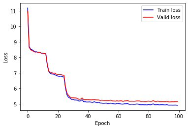

```python
plt.xlabel("Epoch")
plt.ylabel("Loss")
plt.plot(loss_list_train,"blue",label="Train loss")
plt.plot(loss_list_valid,"red",label="Valid loss")
plt.legend(loc=1)
```

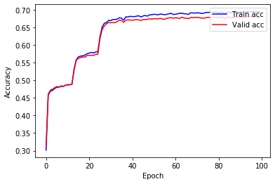

```python
plt.xlabel("Epoch")
plt.ylabel("Accuracy")
plt.plot(acc_list_train,"blue",label="Train acc")
plt.plot(acc_list_valid,"red",label="Valid acc")
plt.legend(loc=1)
```

```python
accuracy(test_x,test_y,w,b)
```

```
<tf.Tensor: shape=(), dtype=float32, numpy=0.6866>
```

## 使用Keras序列模型建模

- 其好处在于可以使用多层神经网络，上面的方法使用多层神经网络比较麻烦

#### Keras序列模型建模的步骤

- 创建Sequential模型；
- 根据需要，通过"add()"在模型中添加所需要的神经网络；
- 编译模型，"Ccompile()"
- 训练模型,"fit()"
- 评估模型，"evaluate()"
- 应用模型，"predict()"

```python
import tensorflow as tf
import matplotlib.pyplot as plt
import numpy as np
import pandas as pd
```

```python
mnist = tf.keras.datasets.mnist
(train_images,train_labels),(test_images,test_labels)=mnist.load_data()
```

```python
train_images = train_images/255.
test_images = test_images/255.
```

```python
train_images_ohe=tf.one_hot(train_labels,depth=10).numpy()#对标签数据进行独热编码
test_images_ohe=tf.one_hot(test_labels,depth=10).numpy()
```

- 建Sequential模型

```python
model = tf.keras.models.Sequential()#空的
```

```python
#添加平坦层，即输入层
model.add(tf.keras.layers.Flatten(input_shape=(28,28)))
```

```python
#添加隐藏层1
model.add(tf.keras.layers.Dense(units=64,kernel_initializer="normal",activation="relu"))
```

```python
#添加隐藏层2
model.add(tf.keras.layers.Dense(units=32,kernel_initializer="normal",activation="relu"))
```

```python
#添加输出层
model.add(tf.keras.layers.Dense(units = 10, activation="softmax"))
```

```python
#输出模型的摘要
model.summary()
```

```
Model: "sequential_2"
_________________________________________________________________
Layer (type)                 Output Shape              Param #
=================================================================
flatten_1 (Flatten)          (None, 784)               0
_________________________________________________________________
dense_2 (Dense)              (None, 64)                50240
_________________________________________________________________
dense_3 (Dense)              (None, 32)                2080
_________________________________________________________________
dense_4 (Dense)              (None, 10)                330
=================================================================
Total params: 52,650
Trainable params: 52,650
Non-trainable params: 0
_________________________________________________________________
```

```python
#上述过程可以一次性添加
'''
model=tf.keras.models.Sequential([
tf.keras.layers.Flatten(input_shape=(28,28)),
tf.keras.layers.Dense(units=64,kernel_initializer="normal",activation="relu"),
tf.keras.layers.Dense(units=32,kernel_initializer="normal",activation="relu"),
tf.keras.layers.Dense(units = 10, activation="softmax")
])
'''
```

```python
## 定义训练模式
model.compile(optimizer="adam",loss="categorical_crossentropy",metrics=["accuracy"])
```

```python
#设置训练参数
training_epochs=20
#learning_rate=0.001
batch_size=30
```

```python
#训练模型
train_history=model.fit(train_images,train_images_ohe,validation_split=0.2,epochs=training_epochs,batch_size=batch_size,verbose=2)
```

```
Train on 48000 samples, validate on 12000 samples
48000/48000 - 3s - loss: 0.0120 - accuracy: 0.9956 - val_loss: 0.1494 - val_accuracy: 0.9741
48000/48000 - 3s - loss: 0.0095 - accuracy: 0.9969 - val_loss: 0.1470 - val_accuracy: 0.9757
48000/48000 - 3s - loss: 0.0129 - accuracy: 0.9956 - val_loss: 0.1602 - val_accuracy: 0.9749
48000/48000 - 3s - loss: 0.0080 - accuracy: 0.9970 - val_loss: 0.1535 - val_accuracy: 0.9741
48000/48000 - 3s - loss: 0.0103 - accuracy: 0.9964 - val_loss: 0.1535 - val_accuracy: 0.9770
48000/48000 - 3s - loss: 0.0104 - accuracy: 0.9965 - val_loss: 0.1769 - val_accuracy: 0.9722
48000/48000 - 3s - loss: 0.0078 - accuracy: 0.9972 - val_loss: 0.1772 - val_accuracy: 0.9718
48000/48000 - 3s - loss: 0.0087 - accuracy: 0.9973 - val_loss: 0.1949 - val_accuracy: 0.9738
48000/48000 - 3s - loss: 0.0084 - accuracy: 0.9971 - val_loss: 0.1919 - val_accuracy: 0.9738
48000/48000 - 3s - loss: 0.0093 - accuracy: 0.9969 - val_loss: 0.1856 - val_accuracy: 0.9753
48000/48000 - 3s - loss: 0.0095 - accuracy: 0.9970 - val_loss: 0.1967 - val_accuracy: 0.9731
48000/48000 - 3s - loss: 0.0049 - accuracy: 0.9984 - val_loss: 0.1806 - val_accuracy: 0.9744
48000/48000 - 3s - loss: 0.0113 - accuracy: 0.9963 - val_loss: 0.1936 - val_accuracy: 0.9740
48000/48000 - 3s - loss: 0.0091 - accuracy: 0.9970 - val_loss: 0.1812 - val_accuracy: 0.9737
48000/48000 - 3s - loss: 0.0058 - accuracy: 0.9983 - val_loss: 0.2262 - val_accuracy: 0.9721
48000/48000 - 3s - loss: 0.0073 - accuracy: 0.9976 - val_loss: 0.2017 - val_accuracy: 0.9728
48000/48000 - 3s - loss: 0.0065 - accuracy: 0.9982 - val_loss: 0.2246 - val_accuracy: 0.9716
48000/48000 - 3s - loss: 0.0097 - accuracy: 0.9969 - val_loss: 0.2022 - val_accuracy: 0.9755
48000/48000 - 3s - loss: 0.0091 - accuracy: 0.9970 - val_loss: 0.2292 - val_accuracy: 0.9725
48000/48000 - 3s - loss: 0.0077 - accuracy: 0.9978 - val_loss: 0.2215 - val_accuracy: 0.9749
```

```python
train_history.history
```

```
{'loss': [0.012048194627298319,
  0.009472951539655865,
  0.01293287297195425,
  0.008003469265788156,
  0.010348925626331091,
  0.010366686388253728,
  0.007800175307798053,
  0.008737101690689779,
  0.008377298101194098,
  0.00933852799349901,
  0.009481034494179655,
  0.004905820947241092,
  0.011295290688163609,
  0.009124467617390547,
  0.00584376608461225,
  0.007260150076957867,
  0.00652269307201702,
  0.009736448974963605,
  0.00908942442551551,
  0.007680555169484565],
 'accuracy': [0.9955625,
  0.9968542,
  0.995625,
  0.99704164,
  0.9963958,
  0.99647915,
  0.9971667,
  0.9972708,
  0.997125,
  0.99689585,
  0.99702084,
  0.998375,
  0.99629164,
  0.9969792,
  0.99825,
  0.99764585,
  0.99820834,
  0.99691665,
  0.997,
  0.99779165],
```

[output cut: 25 more lines]

```
  0.97216666,
  0.97183335,
  0.9738333,
  0.9738333,
  0.97525,
  0.9730833,
  0.9744167,
  0.974,
  0.97375,
  0.97208333,
  0.97275,
  0.9715833,
  0.9755,
  0.9725,
  0.97491664]}
```

```python
## 可视化
import matplotlib.pyplot as plt
def show_train_history(train_history,train_metric,val_metric):
    plt.plot(train_history.history[train_metric])
    plt.plot(train_history.history[val_metric])
    plt.title("Train history")
    plt.ylabel(train_metric)
    plt.xlabel("Epoch")
    plt.legend(["Train","validation"],loc="upper left")
    plt.show
```

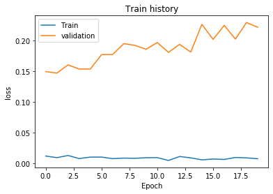

```python
show_train_history(train_history,"loss","val_loss")
```

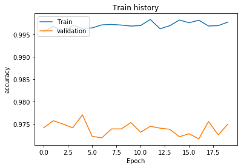

```python
show_train_history(train_history,"accuracy","val_accuracy")
```

```python
## 模型评估
test_loss,test_acc = model.evaluate(test_images,test_images_ohe,verbose=2)
```

```
10000/10000 - 0s - loss: 0.1812 - accuracy: 0.9743
```

```python
## 应用模型
test_pred=model.predict(test_images)
```

```python
test_pred.shape
```

```
(10000, 10)
```

```python
##直接进行分类预测
test_pred=model.predict_classes(test_images)
```

```python
test_pred.shape
```

```
(10000,)
```

```python
test_pred[0]
```

```
7
```

```python
test_labels[0]
```

```
7
```

## 面向整数标签Keras序列模型构建与训练

- 即对上面的例子进行简化
- 采用"sparse_categorical_crossentropy"来替换categorical_crossentropy，且无需针对标签数据进行独热编码

```python
import tensorflow as tf
import matplotlib.pyplot as plt
import numpy as np
import pandas as pd
```

```python
mnist = tf.keras.datasets.mnist
(train_images,train_labels),(test_images,test_labels)=mnist.load_data()
```

```python
train_images = train_images/255.
test_images = test_images/255.
```

```python
model=tf.keras.models.Sequential([
tf.keras.layers.Flatten(input_shape=(28,28)),
tf.keras.layers.Dense(units=64,kernel_initializer="normal",activation="relu"),
tf.keras.layers.Dense(units=32,kernel_initializer="normal",activation="relu"),
tf.keras.layers.Dense(units = 10, activation="softmax")
])
```

```python
model.summary()
```

```
Model: "sequential"
_________________________________________________________________
Layer (type)                 Output Shape              Param #
=================================================================
flatten (Flatten)            (None, 784)               0
_________________________________________________________________
dense (Dense)                (None, 64)                50240
_________________________________________________________________
dense_1 (Dense)              (None, 32)                2080
_________________________________________________________________
dense_2 (Dense)              (None, 10)                330
=================================================================
Total params: 52,650
Trainable params: 52,650
Non-trainable params: 0
_________________________________________________________________
```

```python
model.compile(optimizer="adam",loss="sparse_categorical_crossentropy",metrics=["accuracy"])
```

```python
training_epochs=20
#learning_rate=0.001
batch_size=30
```

```python
train_history=model.fit(train_images,train_labels,validation_split=0.2,epochs=training_epochs,batch_size=batch_size,verbose=2)
```

```
Train on 48000 samples, validate on 12000 samples
48000/48000 - 3s - loss: 0.3627 - accuracy: 0.8965 - val_loss: 0.2012 - val_accuracy: 0.9410
48000/48000 - 3s - loss: 0.1624 - accuracy: 0.9510 - val_loss: 0.1397 - val_accuracy: 0.9588
48000/48000 - 3s - loss: 0.1170 - accuracy: 0.9645 - val_loss: 0.1232 - val_accuracy: 0.9634
48000/48000 - 3s - loss: 0.0926 - accuracy: 0.9726 - val_loss: 0.1169 - val_accuracy: 0.9636
48000/48000 - 3s - loss: 0.0748 - accuracy: 0.9770 - val_loss: 0.1259 - val_accuracy: 0.9643
48000/48000 - 3s - loss: 0.0626 - accuracy: 0.9801 - val_loss: 0.1087 - val_accuracy: 0.9703
48000/48000 - 3s - loss: 0.0538 - accuracy: 0.9826 - val_loss: 0.1233 - val_accuracy: 0.9657
48000/48000 - 3s - loss: 0.0456 - accuracy: 0.9854 - val_loss: 0.1160 - val_accuracy: 0.9697
48000/48000 - 3s - loss: 0.0394 - accuracy: 0.9877 - val_loss: 0.1160 - val_accuracy: 0.9702
48000/48000 - 3s - loss: 0.0350 - accuracy: 0.9887 - val_loss: 0.1184 - val_accuracy: 0.9699
48000/48000 - 3s - loss: 0.0287 - accuracy: 0.9904 - val_loss: 0.1134 - val_accuracy: 0.9734
48000/48000 - 3s - loss: 0.0254 - accuracy: 0.9915 - val_loss: 0.1371 - val_accuracy: 0.9694
48000/48000 - 3s - loss: 0.0226 - accuracy: 0.9926 - val_loss: 0.1309 - val_accuracy: 0.9699
48000/48000 - 3s - loss: 0.0208 - accuracy: 0.9930 - val_loss: 0.1361 - val_accuracy: 0.9707
48000/48000 - 3s - loss: 0.0173 - accuracy: 0.9941 - val_loss: 0.1403 - val_accuracy: 0.9707
48000/48000 - 3s - loss: 0.0170 - accuracy: 0.9942 - val_loss: 0.1508 - val_accuracy: 0.9693
48000/48000 - 3s - loss: 0.0150 - accuracy: 0.9949 - val_loss: 0.1435 - val_accuracy: 0.9722
48000/48000 - 3s - loss: 0.0125 - accuracy: 0.9963 - val_loss: 0.1511 - val_accuracy: 0.9722
48000/48000 - 3s - loss: 0.0143 - accuracy: 0.9952 - val_loss: 0.1595 - val_accuracy: 0.9720
48000/48000 - 3s - loss: 0.0125 - accuracy: 0.9957 - val_loss: 0.1638 - val_accuracy: 0.9714
```

```python
## 可视化
import matplotlib.pyplot as plt
def show_train_history(train_history,train_metric,val_metric):
    plt.plot(train_history.history[train_metric])
    plt.plot(train_history.history[val_metric])
    plt.title("Train history")
    plt.ylabel(train_metric)
    plt.xlabel("Epoch")
    plt.legend(["Train","validation"],loc="upper left")
    plt.show
```

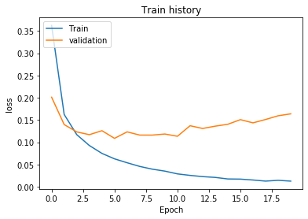

```python
show_train_history(train_history,"loss","val_loss")
```

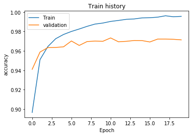

```python
show_train_history(train_history,"accuracy","val_accuracy")
```

```python
test_loss,test_acc = model.evaluate(test_images,test_labels,verbose=2)
```

```
10000/10000 - 0s - loss: 0.1513 - accuracy: 0.9711
```